# HW4

James Zhao

May 21, 2019

# Q1 For this problem, use the dataset of death row statements from Texas inmates.

```r
packages <- c("dplyr", "ggplot2", "lubridate", "stringr", "foreign", "xml2", "rvest", "tm", "tidytext", "proxy", "viridis", "fields", "mixtools", "tidyr", "topicmodels", "stm")
load.packages <- function(x) {
  if (!require(x, character.only = TRUE)) {
    install.packages(x, dependencies = TRUE)
    library(x, character.only = TRUE)
  }
}
lapply(packages, load.packages)
```

[output not shown]

[output not shown]

[output not shown]

[output not shown]

## Q1.1 Import the data, pre-process it, and set up a DTM. For this analysis, do not remove sparse terms, but do remove people who gave no statement.

```r
setwd("~/GitHub/MMSS_311_2")

tx <- read.csv("tx_deathrow_full.csv")
statement <- Corpus(VectorSource(tx$Last.Statement)) %>%
  tm_map(removePunctuation) %>%
  tm_map(removeNumbers) %>%
  tm_map(content_transformer(tolower)) %>%
  tm_map(removeWords, stopwords('english')) %>%
  tm_map(stemDocument) %>%
  tm_map(stripWhitespace)
dtm.statement <- DocumentTermMatrix(statement) %>% as.matrix()

rowTotals <- apply(dtm.statement , 1, sum) #Find the sum of words in each Document
dtm.statement.new   <- dtm.statement[rowTotals> 0, ]

empty_rows <- which(rowSums(as.matrix(dtm.statement)) == 0)
```

## Q1.2 Use LDA to assess topics in the statements, with k = 10 topics. Note: this may take a while to run.

```r
mod.out.10 <- LDA(dtm.statement.new, k=10, control = list(seed=1))
```

## Q1.3 Use tidy to get the results out of the model. Show the top 10 most likely words in each topic.

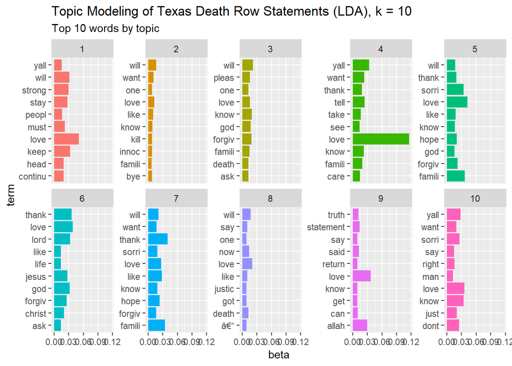

```r
tidy(mod.out.10) %>%
  group_by(topic) %>%
  top_n(10,beta) %>%
  ungroup() %>%
  ggplot(aes(term, beta, fill = factor(topic))) +
  geom_col(show.legend = FALSE) +
  facet_wrap(~ topic, scales = "free_y", nrow = 2) +
  coord_flip() +
  xlab("term") +
  labs(title = "Topic Modeling of Texas Death Row Statements (LDA), k = 10", subtitle = "Top 10 words by topic")
```

```r
tidy(mod.out.10)
```

```
## # A tibble: 26,980 x 3
##    topic term       beta
##    <int> <chr>     <dbl>
##  1     1 execut 4.11e- 3
##  2     2 execut 2.02e- 3
##  3     3 execut 4.41e- 3
##  4     4 execut 5.32e-39
##  5     5 execut 7.02e- 4
##  6     6 execut 1.64e-14
##  7     7 execut 5.74e- 4
##  8     8 execut 4.34e- 3
##  9     9 execut 1.77e- 3
## 10    10 execut 1.05e- 3
## # ... with 26,970 more rows
```

# Q2

## Q2.1 Set up the DTM from Question 1 to be correctly formatted for use with the stm package. Use the code from lecture or the documentation for the package to assist with this.

```r
out <- stm::readCorpus(dtm.statement.new)
```

## Q2.2 Use stm to fit a structural topic model with 10 topics, conditioning on race. Note: This may take a while to run and produce a lot of output. You can use the chunk option {r, results = “hide”} to omit the output from your knitted pdf file.

```r
statement.out <- stm(documents = out$documents, vocab = out$vocab, 10, prevalence = tx$race, data = tx[-empty_rows, ])
```

## Q2.3 Inspect the topics with summary.

```r
summary(statement.out)
```

```
## A topic model with 10 topics, 442 documents and a 2698 word dictionary.
```

```
## Topic 1 Top Words:
##       Highest Prob: thank, like, mom, brother, sister, good, support
##       FREX: thank, mom, chaplain, wife, veronica, sister, book
##       Lift: veronica, cori, grew, amber, maria, doug, mage
##       Score: thank, veronica, dad, book, gomez, doug, buri
## Topic 2 Top Words:
##       Highest Prob: god, lord, jesus, forgiv, love, ask, christ
##       FREX: christ, jesus, heaven, lord, holi, ask, forgiv
##       Lift: roman, salvat, diann, light, damien, inflict, paradis
##       Score: holi, jesus, christ, lord, sin, forgiv, pray
## Topic 3 Top Words:
##       Highest Prob: yall, know, love, dont, want, just, kill
##       FREX: yall, alright, didnt, hate, dont, kid, man
##       Lift: transcript, alba, roger, sidethat, burn, chester, elroy
##       Score: yall, alright, didnt, mean, worri, dont, kill
## Topic 4 Top Words:
##       Highest Prob: know, dont, will, get, want, say, now
##       FREX: â, bye, anyth, allah, wit, execut, mad
##       Lift: fast, happend, rocki, lilia, momrobert, youin, miriam
##       Score: bye, allah, fake, pinkerton, â, robinson, ros
## Topic 5 Top Words:
##       Highest Prob: got, will, want, that, peopl, lie, day
##       FREX: thou, nobodi, adam, hous, lie, green, leadeth
##       Lift: counti, district, herebi, anointest, green, leadeth, maketh
##       Score: thou, green, leadeth, cup, oil, pastur, preparest
## Topic 6 Top Words:
##       Highest Prob: will, innoc, peopl, must, continu, thi, love
##       FREX: lynch, march, trespass, must, daili, thi, black
##       Lift: liber, draw, staci, trix, protest, princess, associ
##       Score: black, lynch, march, must, thi, forward, liber
## Topic 7 Top Words:
##       Highest Prob: sorri, hope, forgiv, famili, peac, will, pain
##       FREX: pain, sorri, caus, hope, find, bring, peac
##       Lift: kehler, sanchez, donovan, intend, resolv, horribl, bother
##       Score: sorri, pain, peac, forgiv, truli, hope, apolog
## Topic 8 Top Words:
##       Highest Prob: love, strong, take, stay, home, bless, care
##       FREX: strong, stay, home, spanish, care, bless, take
##       Lift: throughout, grandmoth, dwight, ranger, grate, joke, melyssa
##       Score: stay, final, strong, home, bless, spanish, crazi
## Topic 9 Top Words:
##       Highest Prob: love, famili, tell, want, yes, warden, friend
##       FREX: tell, appreci, warden, famili, yes, much, friend
##       Lift: mentor, patel, soldier, ten, toe, jean, nighti
##       Score: love, appreci, famili, friend, hurt, everybodi, tell
## Topic 10 Top Words:
##       Highest Prob: love, will, now, one, allah, know, shall
##       FREX: boswel, chanc, shall, act, unto, becom, gift
##       Lift: marcus, rhode, dishonor, dust, sadden, texan, boswel
##       Score: boswel, act, eardmann, woe, asdadu, gift, chief
```

```r
tidy(statement.out)
```

```
## # A tibble: 26,980 x 3
##    topic term        beta
##    <int> <chr>      <dbl>
##  1     1 execut 6.64e- 96
##  2     2 execut 4.40e-  4
##  3     3 execut 1.16e- 45
##  4     4 execut 1.14e-  2
##  5     5 execut 6.21e- 68
##  6     6 execut 6.72e-  3
##  7     7 execut 6.03e-  4
##  8     8 execut 4.51e- 27
##  9     9 execut 1.38e- 42
## 10    10 execut 1.88e-150
## # ... with 26,970 more rows
```

```r
labelTopics(statement.out)
```

```
## Topic 1 Top Words:
##       Highest Prob: thank, like, mom, brother, sister, good, support
##       FREX: thank, mom, chaplain, wife, veronica, sister, book
##       Lift: veronica, cori, grew, amber, maria, doug, mage
##       Score: thank, veronica, dad, book, gomez, doug, buri
## Topic 2 Top Words:
##       Highest Prob: god, lord, jesus, forgiv, love, ask, christ
##       FREX: christ, jesus, heaven, lord, holi, ask, forgiv
##       Lift: roman, salvat, diann, light, damien, inflict, paradis
##       Score: holi, jesus, christ, lord, sin, forgiv, pray
## Topic 3 Top Words:
##       Highest Prob: yall, know, love, dont, want, just, kill
##       FREX: yall, alright, didnt, hate, dont, kid, man
##       Lift: transcript, alba, roger, sidethat, burn, chester, elroy
##       Score: yall, alright, didnt, mean, worri, dont, kill
## Topic 4 Top Words:
##       Highest Prob: know, dont, will, get, want, say, now
##       FREX: â, bye, anyth, allah, wit, execut, mad
##       Lift: fast, happend, rocki, lilia, momrobert, youin, miriam
##       Score: bye, allah, fake, pinkerton, â, robinson, ros
## Topic 5 Top Words:
##       Highest Prob: got, will, want, that, peopl, lie, day
##       FREX: thou, nobodi, adam, hous, lie, green, leadeth
##       Lift: counti, district, herebi, anointest, green, leadeth, maketh
##       Score: thou, green, leadeth, cup, oil, pastur, preparest
## Topic 6 Top Words:
##       Highest Prob: will, innoc, peopl, must, continu, thi, love
##       FREX: lynch, march, trespass, must, daili, thi, black
##       Lift: liber, draw, staci, trix, protest, princess, associ
##       Score: black, lynch, march, must, thi, forward, liber
## Topic 7 Top Words:
##       Highest Prob: sorri, hope, forgiv, famili, peac, will, pain
##       FREX: pain, sorri, caus, hope, find, bring, peac
##       Lift: kehler, sanchez, donovan, intend, resolv, horribl, bother
##       Score: sorri, pain, peac, forgiv, truli, hope, apolog
## Topic 8 Top Words:
##       Highest Prob: love, strong, take, stay, home, bless, care
##       FREX: strong, stay, home, spanish, care, bless, take
##       Lift: throughout, grandmoth, dwight, ranger, grate, joke, melyssa
##       Score: stay, final, strong, home, bless, spanish, crazi
## Topic 9 Top Words:
##       Highest Prob: love, famili, tell, want, yes, warden, friend
##       FREX: tell, appreci, warden, famili, yes, much, friend
##       Lift: mentor, patel, soldier, ten, toe, jean, nighti
##       Score: love, appreci, famili, friend, hurt, everybodi, tell
## Topic 10 Top Words:
##       Highest Prob: love, will, now, one, allah, know, shall
##       FREX: boswel, chanc, shall, act, unto, becom, gift
##       Lift: marcus, rhode, dishonor, dust, sadden, texan, boswel
##       Score: boswel, act, eardmann, woe, asdadu, gift, chief
```

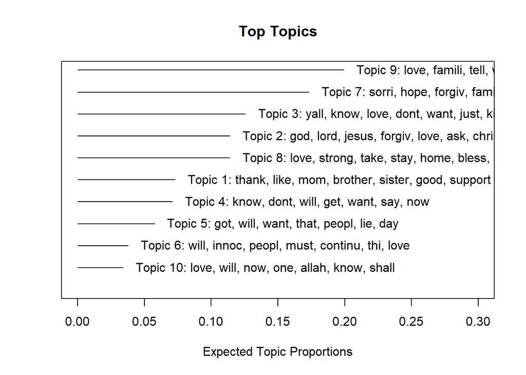

```r
plot.STM(statement.out, type="summary", xlim=c(0,0.3), n=7)
```